# instructor recap notes - lec 20

2023-11-01

```r
# load the required libraries
library(tidyverse)
library(ggplot2)
library(dslabs)
library(broom)
```

### 1. Linear Regression in R

**Definition**: Linear regression is a statistical method that models the relationship between a dependent variable and one or more independent variables by fitting a linear equation to observed data.

#### 1.1 Simple Linear Regression

When there’s just one independent variable, it’s called simple linear regression.

**Equation**: $Y = \beta_0 + \beta_1X + \epsilon$

( *equivalent to $\mathbb{E}(Y|X) = \beta_0 + \beta_1 X$* )

Where:

- $Y$ is the dependent variable.
- $X$ is the independent variable.
- $\beta_0$ is the intercept.
- $\beta_1$ is the slope.
- $\epsilon$ is the error term.

**Example with R**:

We’ll use the `murders` dataset available in `dslabs`. We want to predict `total` (murders) based on the population in million.

```r
library(dslabs)
# Reading in data
data(murders)
# Data wrangling
murders <- murders %>%
  mutate(pop_in_million = population / 1000000)
# Fitting the model
model <- lm(total ~ pop_in_million, data = murders)
```

**Summary of the model**

1. with `summary()`

```r
# Summary of the model
summary(model)
```

```
##
## Call:
## lm(formula = total ~ pop_in_million, data = murders)
##
## Residuals:
##      Min       1Q   Median       3Q      Max
## -112.889  -25.656   -3.687   25.505  217.780
##
## Coefficients:
##                Estimate Std. Error t value Pr(>|t|)
## (Intercept)     -17.127     11.981   -1.43    0.159
## pop_in_million   33.164      1.315   25.23   <2e-16 ***
## ---
## Signif. codes:  0 '***' 0.001 '**' 0.01 '*' 0.05 '.' 0.1 ' ' 1
##
## Residual standard error: 63.77 on 49 degrees of freedom
## Multiple R-squared:  0.9285, Adjusted R-squared:  0.9271
## F-statistic: 636.5 on 1 and 49 DF,  p-value: < 2.2e-16
```

2. with `tidy()`

```r
# Tidy summary of the model (broom package)
library(broom)
tidy(model)
```

```
## # A tibble: 2 × 5
##   term           estimate std.error statistic  p.value
##   <chr>             <dbl>     <dbl>     <dbl>    <dbl>
## 1 (Intercept)       -17.1     12.0      -1.43 1.59e- 1
## 2 pop_in_million     33.2      1.31     25.2  9.96e-30
```

3. with `glance()`

```r
# One row summary model fit statistics
glance(model)
```

```
## # A tibble: 1 × 12
##   r.squared adj.r.squared sigma statistic  p.value    df logLik   AIC   BIC
##       <dbl>         <dbl> <dbl>     <dbl>    <dbl> <dbl>  <dbl> <dbl> <dbl>
## 1     0.929         0.927  63.8      636. 9.96e-30     1  -283.  573.  578.
## # ℹ 3 more variables: deviance <dbl>, df.residual <int>, nobs <int>
```

**Using pipe operators**

```r
# Using pipe and summary
murders %>%
  mutate(pop_in_million = population / 1000000) %>%
  lm(total ~ pop_in_million, data = .) %>%
  summary()
```

```
##
## Call:
## lm(formula = total ~ pop_in_million, data = .)
##
## Residuals:
##      Min       1Q   Median       3Q      Max
## -112.889  -25.656   -3.687   25.505  217.780
##
## Coefficients:
##                Estimate Std. Error t value Pr(>|t|)
## (Intercept)     -17.127     11.981   -1.43    0.159
## pop_in_million   33.164      1.315   25.23   <2e-16 ***
## ---
## Signif. codes:  0 '***' 0.001 '**' 0.01 '*' 0.05 '.' 0.1 ' ' 1
##
## Residual standard error: 63.77 on 49 degrees of freedom
## Multiple R-squared:  0.9285, Adjusted R-squared:  0.9271
## F-statistic: 636.5 on 1 and 49 DF,  p-value: < 2.2e-16
```

```r
# Using pipe and tidy
murders %>%
  mutate(pop_in_million = population / 1000000) %>%
  lm(total ~ pop_in_million, data = .) %>%
  tidy()
```

```
## # A tibble: 2 × 5
##   term           estimate std.error statistic  p.value
##   <chr>             <dbl>     <dbl>     <dbl>    <dbl>
## 1 (Intercept)       -17.1     12.0      -1.43 1.59e- 1
## 2 pop_in_million     33.2      1.31     25.2  9.96e-30
```

```r
# Using pipe and glance
murders %>%
  mutate(pop_in_million = population / 1000000) %>%
  lm(total ~ pop_in_million, data = .) %>%
  glance()
```

```
## # A tibble: 1 × 12
##   r.squared adj.r.squared sigma statistic  p.value    df logLik   AIC   BIC
##       <dbl>         <dbl> <dbl>     <dbl>    <dbl> <dbl>  <dbl> <dbl> <dbl>
## 1     0.929         0.927  63.8      636. 9.96e-30     1  -283.  573.  578.
## # ℹ 3 more variables: deviance <dbl>, df.residual <int>, nobs <int>
```

**Fit stratified models following `group_by()`**

```r
# Group by a binary region (Northeast+North Central vs. South+West) then fit model
murders <- murders %>%
  mutate(region_bin = case_when(
    region %in% c("Northeast", "North Central") ~ "Region 1",
    region %in% c("South", "West") ~ "Region 2"
  ),
  region_bin = as.factor(region_bin))

# Is the following code correct?
murders %>% group_by(region_bin) %>%
  lm(total ~ pop_in_million, data = .)
```

```
##
## Call:
## lm(formula = total ~ pop_in_million, data = .)
##
## Coefficients:
##    (Intercept)  pop_in_million
##         -17.13           33.16
```

```r
# The above yield the same results as the following, group_by() didn't work
murders %>% lm(total ~ pop_in_million, data = .)
```

```
##
## Call:
## lm(formula = total ~ pop_in_million, data = .)
##
## Coefficients:
##    (Intercept)  pop_in_million
##         -17.13           33.16
```

```r
# Use do() with tidy()
murders %>% group_by(region_bin) %>%
  do(lm(total ~ pop_in_million, data = .) %>% tidy())
```

```
## # A tibble: 4 × 6
## # Groups:   region_bin [2]
##   region_bin term           estimate std.error statistic  p.value
##   <fct>      <chr>             <dbl>     <dbl>     <dbl>    <dbl>
## 1 Region 1   (Intercept)      -25.5      20.8     -1.23  2.35e- 1
## 2 Region 1   pop_in_million    31.4       2.72    11.5   5.00e-10
## 3 Region 2   (Intercept)       -6.49     14.8     -0.440 6.63e- 1
## 4 Region 2   pop_in_million    33.6       1.48    22.8   1.33e-19
```

#### 1.2 Multiple Linear Regression

When there’s more than one independent variable, it’s called multiple linear regression.

**Equation**: $Y = \beta_0 + \beta_1X_1 + \beta_2X_2 + ... + \epsilon$

**Example with R**:

Using the `murders` dataset again, we’ll predict `total` based on both the population in million (`pop_in_million`) and the dichotomized region variable (`region_bin`).

```r
# Data wrangling to create pop_in_million and region_bin
murders <- murders %>% mutate(
  pop_in_million = population / 1000000,
  egion_bin = case_when(
    region %in% c("Northeast", "North Central") ~ "Region 1",
    region %in% c("South", "West") ~ "Region 2"
  ),
  region_bin = as.factor(region_bin)
)
# Fitting the model
model_multi <- lm(total ~ pop_in_million + region_bin, data = murders)

# Summary of the model
summary(model_multi)
```

```
##
## Call:
## lm(formula = total ~ pop_in_million + region_bin, data = murders)
##
## Residuals:
##      Min       1Q   Median       3Q      Max
## -126.104  -32.747   -1.945   17.148  204.404
##
## Coefficients:
##                    Estimate Std. Error t value Pr(>|t|)
## (Intercept)         -35.629     15.524  -2.295   0.0261 *
## pop_in_million       33.091      1.285  25.743   <2e-16 ***
## region_binRegion 2   32.210     17.743   1.815   0.0757 .
## ---
## Signif. codes:  0 '***' 0.001 '**' 0.01 '*' 0.05 '.' 0.1 ' ' 1
##
## Residual standard error: 62.33 on 48 degrees of freedom
## Multiple R-squared:  0.9331, Adjusted R-squared:  0.9303
## F-statistic: 334.8 on 2 and 48 DF,  p-value: < 2.2e-16
```

```r
# Alternatively, summary of coefficient estimate using tidy
tidy(model_multi)
```

```
## # A tibble: 3 × 5
##   term               estimate std.error statistic  p.value
##   <chr>                 <dbl>     <dbl>     <dbl>    <dbl>
## 1 (Intercept)           -35.6     15.5      -2.30 2.61e- 2
## 2 pop_in_million         33.1      1.29     25.7  9.61e-30
## 3 region_binRegion 2     32.2     17.7       1.82 7.57e- 2
```

**Change the reference level for a factor covariate / predictor / feature**

```r
murders %>% mutate(
  region_bin = relevel(region_bin, ref = "Region 2")
) %>%
  lm(total ~ pop_in_million + region_bin, data = .) %>%
  summary()
```

```
##
## Call:
## lm(formula = total ~ pop_in_million + region_bin, data = .)
##
## Residuals:
##      Min       1Q   Median       3Q      Max
## -126.104  -32.747   -1.945   17.148  204.404
##
## Coefficients:
##                    Estimate Std. Error t value Pr(>|t|)
## (Intercept)          -3.419     13.933  -0.245   0.8072
## pop_in_million       33.091      1.285  25.743   <2e-16 ***
## region_binRegion 1  -32.210     17.743  -1.815   0.0757 .
## ---
## Signif. codes:  0 '***' 0.001 '**' 0.01 '*' 0.05 '.' 0.1 ' ' 1
##
## Residual standard error: 62.33 on 48 degrees of freedom
## Multiple R-squared:  0.9331, Adjusted R-squared:  0.9303
## F-statistic: 334.8 on 2 and 48 DF,  p-value: < 2.2e-16
```

#### 1.3 (Optional) Assumptions of Linear Regression and Model Diagnostics

1. **Linearity**: The relationship between the independent and dependent variable is linear.
2. **Independence**: The residuals are independent.
3. **Homoscedasticity**: The residuals have constant variance.
4. **Normality**: The residuals are normally distributed.

We can check these assumptions in R using various diagnostic plots:

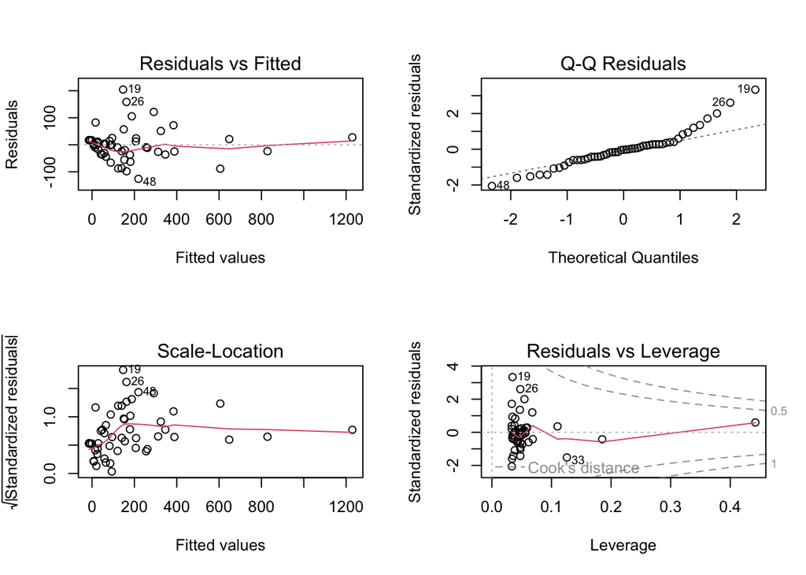

```r
# Diagnostic plots
par(mfrow = c(2, 2)) # Layout for 4 plots
plot(model_multi)
```

```r
# Diagnostic metrics
glance(model_multi)
```

```
## # A tibble: 1 × 12
##   r.squared adj.r.squared sigma statistic  p.value    df logLik   AIC   BIC
##       <dbl>         <dbl> <dbl>     <dbl>    <dbl> <dbl>  <dbl> <dbl> <dbl>
## 1     0.933         0.930  62.3      335. 6.44e-29     2  -282.  571.  579.
## # ℹ 3 more variables: deviance <dbl>, df.residual <int>, nobs <int>
```

AIC (Akaike Information Criterion) and BIC (Bayesian Information Criterion) are both measures used to evaluate the goodness-of-fit of a statistical model. They are particularly useful when comparing multiple models, helping to determine which model is the best fit for the data while considering the complexity of the model.

1. **AIC (Akaike Information Criterion)**:
   - Developed by Hirotugu Akaike in 1974.
   - It estimates the relative amount of information lost by a given model.
   - Formula: $\text{AIC} = 2k - 2\ln(L)$
     - $k$ is the number of model parameters (i.e., the number of variables in the model).
     - $L$ is the maximum likelihood estimation for the model.
   - AIC takes into account the complexity of a model. It penalizes models that have more parameters (to avoid overfitting), favoring simpler models unless the more complex model provides a significantly better fit.
2. **BIC (Bayesian Information Criterion)**:
   - Similar to AIC, but it has a stricter penalty for models with more parameters.
   - Formula: $\text{BIC} = \ln(n)k - 2\ln(L)$
     - $n$ is the number of observations.
     - $k$ is the number of model parameters.
     - $L$ is the maximum likelihood estimation for the model.
3. **AIC vs. BIC**:
   - While both AIC and BIC penalize the complexity of the model, BIC penalizes model complexity more heavily.
   - AIC tends to favor larger models (i.e., models with more parameters) compared to BIC.
   - The choice between AIC and BIC may depend on the goals of the analysis. In situations where it’s crucial to avoid overfitting, BIC might be preferred because of its stricter penalty on model complexity.

In summary, both AIC and BIC are used to compare and select the best model among a set of candidate models, with lower values indicating better models. They both penalize model complexity, helping to strike a balance between fit and parsimony, but BIC usually imposes a heavier penalty than AIC.

#### 1.4 Predictions

Once you have a model, you can use it to predict on new data:

```r
# Sample new data
new_data <- data.frame(region_bin = "Region 1", pop_in_million = 8)

# Predicting mpg for the new data
predict(model_multi, newdata = new_data)
```

```
##        1
## 229.1007
```

### 2. Tips:

- Check the assumptions of linear regression before interpreting the results.
- Consider multicollinearity in multiple linear regression. This is when two or more independent variables are highly correlated.
- Consider other models or transformations if linear regression assumptions are not met.

### 3. Today’s lecture

- HW3 due Nov 5 (2 late days)
- Midterm to be released on Nov 8 (due Nov 22) **no free late days**
- Final project options released on our [course website](https://coredatascience-fa23.github.io/project/). Follow the instructions and fill out the [preference form](https://docs.google.com/forms/d/e/1FAIpQLSfvhegiqPG-jQtQvqaIz6jnyLrSv-sOpiF4V3qvQdSTMHK3zQ/viewform) by **Nov 6**.
- Find a time (office hours preferably) to meet with TF (20 minutes) before Nov 17 to review your project.
- Today: Regression (confounding), machine learning intro